# Tidy data and ggplot2

Jose Eduardo Meireles

July 2026

`spectrolab`’s native representation – one row per sample, one column per band (see `as.matrix()`/`as.data.frame()` in the Introduction vignette) – is *wide*. That’s the right shape for the linear-algebra-heavy operations the rest of the package does (resampling, splicing, smoothing), but it’s the wrong shape for `ggplot2` and most tidyverse workflows, which expect *long* data: one row per observation, here one row per sample-and-band. This vignette covers the bridge between the two.

```r
library(spectrolab)
spec = as_spectra(spec_matrix_example, name_idx = 1)
```

## `to_long()`: dependency-free reshaping

`to_long()` uses only base R – no tidyverse packages required – and returns a long data.frame with `sample_name`, `band`, `value`, and (by default) your metadata columns repeated once per band.

```r
long = to_long(spec)
dim(long)     # one row per sample x band: 50 samples * 2101 bands
```

```
#> [1] 105050      3
```

```r
head(long)
```

```
#>   sample_name band      value
#> 1   species_7  400 0.04099999
#> 2   species_8  400 0.04099620
#> 3   species_5  400 0.04100099
#> 4   species_7  400 0.04099837
#> 5  species_10  400 0.04099914
#> 6   species_1  400 0.04099972
```

Metadata is included by default; drop it with `metadata = FALSE` if you don’t need it (smaller output, and metadata columns to the same value get repeated once per band).

```r
long_no_meta = to_long(spec, metadata = FALSE)
names(long_no_meta)
```

```
#> [1] "sample_name" "band"        "value"
```

## `as_tibble()`: the same thing, as a tibble

If you have the `tibble` package installed, `as_tibble()` is defined for `spectra` objects and wraps `to_long()`:

```r
tbl = tibble::as_tibble(spec)
tbl
```

```
#> # A tibble: 105,050 × 3
#>    sample_name  band  value
#>    <chr>       <dbl>  <dbl>
#>  1 species_7     400 0.0410
#>  2 species_8     400 0.0410
#>  3 species_5     400 0.0410
#>  4 species_7     400 0.0410
#>  5 species_10    400 0.0410
#>  6 species_1     400 0.0410
#>  7 species_2     400 0.0410
#>  8 species_9     400 0.0410
#>  9 species_9     400 0.0410
#> 10 species_6     400 0.0410
#> # ℹ 105,040 more rows
```

## `autoplot()`: a `ggplot2` view

If you have `ggplot2` installed, `autoplot()` draws one line per sample on the wavelength/value plane – a `ggplot2` equivalent of `plot.spectra()` (see the Introduction vignette), useful when you want to layer `ggplot2` facets, themes, or additional geoms on top.

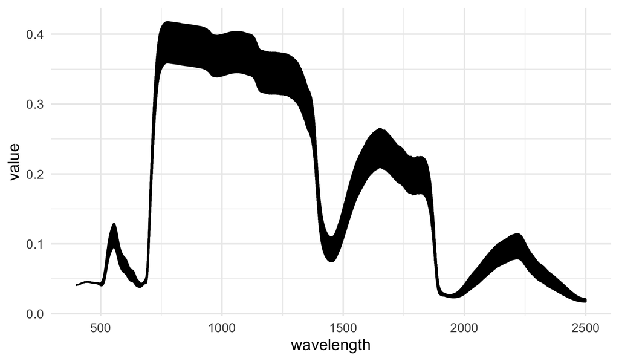

```r
ggplot2::autoplot(spec) + ggplot2::theme_minimal()
```

Because `autoplot()` returns a plain `ggplot` object, it composes with the rest of the grammar normally – facet by a metadata column, recolor by group, add a theme, etc.

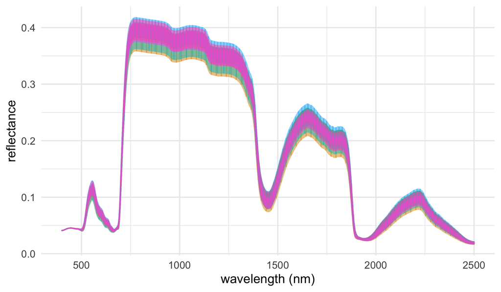

```r
long = to_long(spec)

ggplot2::ggplot(long, ggplot2::aes(x = band, y = value, group = sample_name, color = sample_name)) +
    ggplot2::geom_line(show.legend = FALSE, alpha = 0.5) +
    ggplot2::theme_minimal() +
    ggplot2::labs(x = "wavelength (nm)", y = "reflectance")
```

## Gotchas

- **`tibble` and `ggplot2` are optional.** Both are in `Suggests`, not `Imports` – `to_long()` never needs them, but `as_tibble()` and `autoplot()` will stop with a clear message telling you which package to install if it’s missing, rather than a cryptic “could not find function” error.
- **Long format is much bigger than wide.** Reshaping to long duplicates `sample_name` (and every metadata column) once per band – for this vignette’s small example (50 samples x 2101 bands) that’s 105,050 rows for three columns. On a real dataset with many samples and full-resolution (2000+ band) spectra, `to_long()`/`as_tibble()` can produce a data.frame far larger than the original `spectra` object; use `metadata = FALSE` if you don’t need the repeated metadata columns, and prefer working in wide format (`value()`, `as.matrix()`) for anything performance-sensitive.
- **This bridge is one-way.** There is no `as_spectra.tbl_df`/`from_long()` that reconstructs a `spectra` object from long data – go back through `as_spectra()` on a wide matrix/data.frame (e.g. after a `tidyr::pivot_wider()`) if you need to return to `spectra`.